# Computer Assignment 5 Phase 1

Negar Moradi 810198543

```python
import numpy as np
import pandas as pd
import cv2
import matplotlib.pyplot as plt
import cv2
import random
```

## Visualizing and Preprocessing

```python
path = r'C:\Users\negar\Downloads\AI\CA5 P1\cifar_dataset'
```

```python
labels = pd.read_csv(path + "\labels.csv")
labels
```

|  | id | label |
| --- | --- | --- |
| 0 | 8 | horse |
| 1 | 10 | cat |
| 2 | 12 | horse |
| 3 | 13 | horse |
| 4 | 18 | cat |
| ... | ... | ... |
| 9995 | 49979 | horse |
| 9996 | 49980 | cat |
| 9997 | 49983 | cat |
| 9998 | 49984 | cat |
| 9999 | 49987 | horse |

10000 rows × 2 columns

```python
TRAIN_S = 9000
TEST_S = 1000

train_df = pd.DataFrame()
test_df = pd.DataFrame()

train_df['img'] = []
train_df['name'] = []
train_df['label'] = []

for i in range(TRAIN_S):
    id = labels['id'][i]
    pth = path + "\data" + "\\" + str(id) + ".png"
    img = cv2.imread(pth, cv2.IMREAD_GRAYSCALE)
    imgdt = {'img': [img] ,'name': id , 'label': labels['label'][i]}
    train_df = train_df.append(pd.DataFrame(imgdt) , ignore_index=True)

test_df['img'] = []
test_df['name'] = []
test_df['label'] = []

for i in range(TRAIN_S, TRAIN_S + TEST_S):
    id = labels['id'][i]
    pth = path + "\data" + "\\" + str(id) + ".png"
    img = cv2.imread(pth, cv2.IMREAD_GRAYSCALE)
    imgdt = {'img': [img] ,'name': id , 'label': labels['label'][i]}
    test_df = test_df.append(pd.DataFrame(imgdt) , ignore_index=True)

print(train_df)
print(test_df)
```

```
                                                    img     name  label
0     [[33, 33, 41, 75, 76, 43, 41, 56, 69, 77, 102,...      8.0  horse
1     [[123, 102, 92, 99, 100, 136, 171, 170, 142, 9...     10.0    cat
2     [[147, 171, 168, 172, 200, 212, 196, 135, 119,...     12.0  horse
3     [[203, 200, 200, 201, 200, 201, 202, 202, 201,...     13.0  horse
4     [[104, 135, 144, 130, 81, 55, 48, 51, 52, 53, ...     18.0    cat
...                                                 ...      ...    ...
8995  [[252, 251, 251, 251, 251, 251, 251, 251, 251,...  44988.0    cat
8996  [[55, 50, 62, 51, 68, 85, 81, 101, 78, 98, 123...  45001.0  horse
8997  [[45, 46, 47, 46, 47, 48, 48, 49, 48, 73, 121,...  45013.0    cat
8998  [[146, 156, 158, 159, 156, 152, 147, 129, 97, ...  45027.0    cat
8999  [[45, 43, 39, 37, 36, 36, 30, 37, 32, 32, 33, ...  45028.0  horse

[9000 rows x 3 columns]
                                                   img     name  label
0    [[43, 43, 65, 111, 135, 119, 60, 42, 54, 67, 1...  45030.0  horse
1    [[241, 239, 239, 239, 239, 239, 239, 238, 237,...  45032.0  horse
2    [[47, 38, 64, 71, 60, 55, 55, 64, 38, 44, 53, ...  45035.0  horse
3    [[24, 26, 28, 31, 35, 37, 41, 42, 40, 36, 33, ...  45037.0  horse
4    [[137, 76, 119, 148, 144, 141, 138, 138, 133, ...  45039.0    cat
..                                                 ...      ...    ...
995  [[161, 82, 104, 107, 104, 103, 108, 118, 126, ...  49979.0  horse
996  [[4, 4, 5, 0, 65, 174, 166, 153, 153, 150, 113...  49980.0    cat
997  [[41, 38, 38, 39, 41, 41, 43, 45, 46, 48, 49, ...  49983.0    cat
998  [[31, 31, 29, 31, 33, 36, 37, 41, 87, 146, 164...  49984.0    cat
999  [[140, 141, 142, 142, 142, 143, 143, 144, 144,...  49987.0  horse

[1000 rows x 3 columns]
```

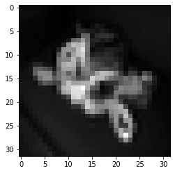

```
maximum 243
minimum 5
```

```python
img = random.choice(train_df['img'])
plt.imshow(img , cmap = 'gray')
plt.show()

print("maximum" ,np.amax(img))
print("minimum" ,np.amin(img))
```

Each pixel has a value between 0 and 255

```
['horse' 'cat']
class:  horse
```

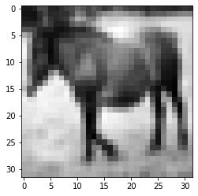

```
class:  cat
```

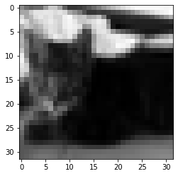

```python
classes = labels['label'].unique()
print(classes)

imgclass = []
for cls in classes:
    index = labels[labels["label"]==cls].head().first_valid_index()
    print("class: ", cls)
    plt.imshow(train_df['img'][index], cmap = 'gray')
    plt.show( block=False )
```

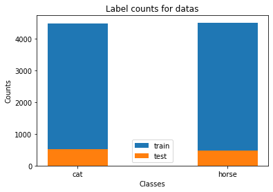

```python
train_num = {'cat':0 ,'horse':0}
test_num = {'cat':0 ,'horse':0}
for cls in classes:
    trnumb = train_df[train_df["label"]==cls]['label'].value_counts()
    train_num[cls] = trnumb[cls]
    tsnumb = test_df[test_df["label"]==cls]['label'].value_counts()
    test_num[cls] = tsnumb[cls]

train_keys = list(train_num.keys())
train_values = list(train_num.values())

test_keys = list(test_num.keys())
test_values = list(test_num.values())


plt.bar(range(len(train_num)), train_values, width = 0.4, tick_label = train_keys, label = 'train')
plt.bar(range(len(test_num)), test_values, width = 0.4, tick_label = test_keys, label = 'test')
plt.xlabel("Classes")
plt.ylabel("Counts")
plt.title("Label counts for datas")
plt.legend()
```

##### Normalization

Normalizing data has several benefits.  
By normalizing the pixels in an image, we can eliminate distortions caused by light and shadows. It may thus produce a better result.  
Numbers between 0 and 255 create a huge difference between features and it would have lots of effect on our gradients, whereas numbers between 0 and 1 make the distinction more moderate. So we don't let our gradients run out of control.  
To normalize our data, we divide it by 255.

```python
train_df['img'] = train_df['img']/255
test_df['img'] = test_df['img']/255

train_df
```

|  | img | name | label |
| --- | --- | --- | --- |
| 0 | [[0.12941176470588237, 0.12941176470588237, 0.... | 8.0 | horse |
| 1 | [[0.4823529411764706, 0.4, 0.3607843137254902,... | 10.0 | cat |
| 2 | [[0.5764705882352941, 0.6705882352941176, 0.65... | 12.0 | horse |
| 3 | [[0.796078431372549, 0.7843137254901961, 0.784... | 13.0 | horse |
| 4 | [[0.40784313725490196, 0.5294117647058824, 0.5... | 18.0 | cat |
| ... | ... | ... | ... |
| 8995 | [[0.9882352941176471, 0.984313725490196, 0.984... | 44988.0 | cat |
| 8996 | [[0.21568627450980393, 0.19607843137254902, 0.... | 45001.0 | horse |
| 8997 | [[0.17647058823529413, 0.1803921568627451, 0.1... | 45013.0 | cat |
| 8998 | [[0.5725490196078431, 0.611764705882353, 0.619... | 45027.0 | cat |
| 8999 | [[0.17647058823529413, 0.16862745098039217, 0.... | 45028.0 | horse |

9000 rows × 3 columns

```python
train_reshape = [np.reshape(row, 1024) for row in train_df['img']]
indexes = [i for i in range(1024)]
train = pd.DataFrame(train_reshape, columns=indexes)

test_reshape = [np.reshape(row, 1024) for row in test_df['img']]
test = pd.DataFrame(test_reshape, columns=indexes)

train_labels = train_df['label']
test_labels = test_df['label']
```

# Dataloader

```python
BASE = 0.00000000001

class Dataloader:

    def __init__(self, data, labels, n_classes, batch_size=None, shuffle=False):

        assert len(data)==len(labels)
        self.__n_classes = n_classes
        self.__batch_size = batch_size
        self.__shuffle = shuffle
        self.__data = data
        self.__onehot_labels = self.__onehot(labels, self.__n_classes)

    def __onehot(self, labels, n_classes):
        onehot_vectors = []
        for val in labels:
            row = [1 if i == val else 0 for i in n_classes]
            onehot_vectors.append(row)
        onehot_vectors = np.asmatrix(onehot_vectors, dtype=float)

        return onehot_vectors

    def __shuffle_dataset(self):
        perm = np.random.permutation((self.__data.shape[0]))
        self.__data = self.__data.loc[perm]
        self.__onehot_labels = self.__onehot_labels[perm]

    def __iter__(self):

        if self.__shuffle:
            self.__shuffle_dataset()

        if self.__batch_size==None:
            yield (np.matrix(self.__data), np.matrix(self.__onehot_labels))
            return

        for idx in range(0, len(self.__data), self.__batch_size):
            yield (np.matrix(self.__data[idx:idx+self.__batch_size]),
                   np.matrix(self.__onehot_labels[idx:idx+self.__batch_size]))
```

# Activation Functions

An activation function in a neural network defines how the weighted sum of the input is transformed into an output from a node or nodes in a layer of the network.

$$ Relu(x) = \begin{cases} x & x \geq 0\\ 0 & x < 0 \end{cases} \quad \text{and} \quad Relu'(x) = \begin{cases} 1 & x \geq 0\\ 0 & x < 0 \end{cases} $$

$$ LeakyRelu(x) = \begin{cases} x & x > 0\\ \text{negative_slope}*x & x \leq 0 \end{cases} \quad \text{and} \quad LeakyRelu'(x) = \begin{cases} 1 & x > 0\\ \text{negative_slope} & x \leq 0 \end{cases} $$

$$ Sigmoid(x) = \frac{1}{1+e^{-x}} \quad \text{and} \quad Sigmoid'(x) = Sigmoid(x)(1-Sigmoid(x)) $$

$ Softmax(matrix) = $

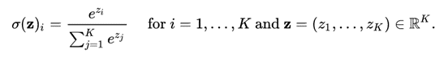

$$ Tanh(x) = \frac{e^{x}-e^{-x}}{e^{x}+e^{-x}} \quad \text{and} \quad Tanh'(x) = 1-Tanh(x)^2 $$

```python
class Identical:

    def __init__(self): pass

    def __val(self, matrix):
        identical_value = np.matrix(matrix, dtype=float)
        return identical_value

    def derivative(self, matrix):
        temp = np.matrix(matrix, dtype=float)
        identical_derivative = np.matrix(np.full(np.shape(temp), 1.))
        return identical_derivative

    def __call__(self, matrix):
        return self.__val(matrix)


class Relu:

    def __init__(self): pass

    def __val(self, matrix):
        x = np.matrix(matrix, dtype=float)
        relu_value = np.maximum(0, x)
        return relu_value

    def derivative(self, matrix):
        relu_derivative = np.matrix(matrix, dtype=float)
        relu_derivative[relu_derivative >= 0] = 1
        relu_derivative[relu_derivative < 0] = 0
        return relu_derivative

    def __call__(self, matrix):
        return self.__val(matrix)


class LeakyRelu:
    def __init__(self, negative_slope=0.01):
        self.negative_slope = 0.01

    def __val(self, matrix):
        matrixs = np.where(matrix >= 0, matrix, matrix * self.negative_slope)
        leacky_relu_value = np.matrix(matrixs, dtype=float)
        return leacky_relu_value

    def derivative(self, matrix):
        temp = np.matrix(matrix, dtype = float)
        leacky_relu_derivative = np.where(temp >= 0, 1, self.negative_slope)
        return leacky_relu_derivative

    def __call__(self, matrix):
        return self.__val(matrix)


class Sigmoid:
    def __init__(self): pass

    def __val(self, matrix):
        sigmoid_value = np.matrix(1/(1 + np.exp(-matrix)), dtype = float)
        return sigmoid_value

    def derivative(self, matrix):
        temp = np.matrix(matrix, dtype = float)
        val = self.__call__(temp)
        sigmoid_derivative = np.multiply(val, (1 - val))
        return sigmoid_derivative

    def __call__(self, matrix):
        return self.__val(matrix)


class Softmax:
    def __init__(self): pass

    def __val(self, matrix):
        def softmax(row):
            row -= np.max(row)
            sftmax = np.exp(row)/(np.exp(row)).sum()
            return sftmax
        softmax_value = np.apply_along_axis(softmax, 1, np.matrix(matrix, dtype=float))

        return softmax_value

    def __call__(self, matrix):
        return self.__val(matrix)

class Tanh:

    def __init__(self): pass

    def __val(self, matrix):
        temp = np.matrix(matrix, dtype=float)
        tanh_value = np.tanh(temp)
        return tanh_value

    def derivative(self, matrix):
        temp = np.matrix(matrix, dtype=float)
        tanh_value = self.__val(temp)
        tanh_derivative = 1 - np.multiply(tanh_value, tanh_value)
        return tanh_derivative

    def __call__(self, matrix):
        return self.__val(matrix)
```


# Loss Function

```python
class CrossEntropy: #(with softmax)
    def __init__(self): pass

    def __val(self, true_val, expected_val):
        assert np.shape(true_val)==np.shape(expected_val)
        true_temp = np.matrix(true_val , dtype=float)
        softmax = Softmax()
        expected_val_temp = np.matrix(expected_val, dtype=float)
        true_temp = true_temp + BASE
        sftmax = softmax(true_temp) + BASE
        cross_entropy_value = np.sum(-np.multiply(expected_val_temp, np.log(sftmax)), axis=1)
        return cross_entropy_value

    def derivative(self, true_val, expected_val):
        assert np.shape(true_val)==np.shape(expected_val)
        true_temp = np.matrix(true_val , dtype=float)
        softmax = Softmax()
        expected_val_temp = np.matrix(expected_val, dtype=float)
        cross_entropy_derivative = softmax(true_temp) - expected_val_temp
        return cross_entropy_derivative

    def __call__(self, true_val, expected_val):
        return self.__val(true_val, expected_val)
```

# Layer

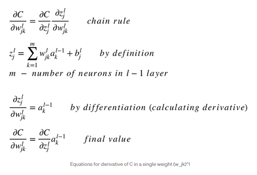

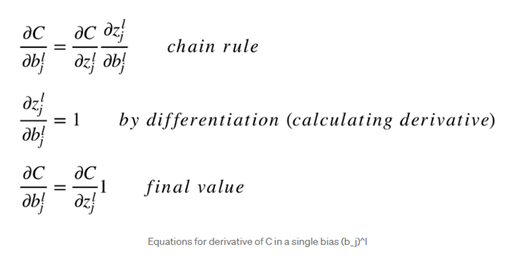

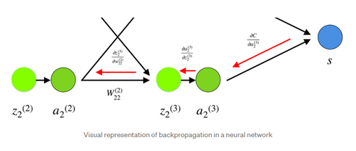

Following the above proofs, we updated weights and biases at the end of each batch using the following formulas.

$$ \frac{\partial L}{\partial W} = x^T\frac{\partial L}{\partial y} $$$$ \frac{\partial L}{\partial b} = 1\frac{\partial L}{\partial y} $$$$ \frac{\partial L}{\partial x} = \frac{\partial L}{\partial y}W^T $$

```python
class Layer:
    DEFAULT_LOW, DEFAULT_HIGH, DEFAULT_MEAN, DEFAULT_VAR = 0, 0.05, 0., 1.

    def __init__(self, input_size, output_size, activation=Identical(), initial_weight='uniform',
                 **initializing_parameters):

        assert type(initial_weight)==str, 'Undefined activation function!'

        self.__weight_initializer_dict = {'uniform':self.__uniform_weight, 'normal':self.__normal_weight}

        assert initial_weight in self.__weight_initializer_dict, 'Undefined weight initialization function!'


        self.__n_neurons = output_size
        weight_initializer = self.__weight_initializer_dict[initial_weight]
        self.__weight = weight_initializer(input_size, self.__n_neurons, **initializing_parameters)
        self.__bias = weight_initializer(1, self.__n_neurons, **initializing_parameters)
        self.__activation = activation

        self.__last_input = None
        self.__last_activation_input = None
        self.__last_activation_output = None
        self.__last_activation_derivative = None

    def forward(self, layer_input):

        assert np.ndim(layer_input)==2
        assert np.size(self.__weight,0) == np.size(layer_input,1)
        temp_layer = np.matrix(layer_input, dtype=float)
        self.__last_input = temp_layer
        self.__last_activation_input = np.add((layer_input * self.__weight), self.__bias)
        self.__last_activation_output = self.__activation(self.__last_activation_input)
        self.__last_activation_derivative = self.activation.derivative(self.__last_activation_input)
        return self.__last_activation_output

    def update_weights(self, backprop_tensor, lr):
        assert np.ndim(backprop_tensor)==2
        assert np.size(backprop_tensor,0) == np.size(self.__last_activation_derivative,0)
        assert np.size(backprop_tensor,1) == self.__n_neurons

        dL_dY = np.multiply(np.matrix(backprop_tensor, dtype=float), self.__last_activation_derivative)
        backprop_tensor = np.dot(dL_dY, self.__weight.transpose())

        dL_dW = np.dot(self.__last_input.T, dL_dY)

        bias_t = np.ones((1, dL_dY.shape[0]))
        dL_dB = np.dot(bias_t, dL_dY)

        self.__bias -= (lr * dL_dB)
        self.__weight -= (lr * dL_dW)


        return backprop_tensor

    def __uniform_weight(self, dim1, dim2, **initializing_parameters):
        low, high = self.DEFAULT_LOW, self.DEFAULT_HIGH
        if 'low' in initializing_parameters.keys(): low = initializing_parameters['low']
        if 'high' in initializing_parameters.keys(): high = initializing_parameters['high']

        weights = np.random.uniform(low = low, high = high, size = (dim1, dim2))
        weights = np.matrix(weights)

        return weights

    def __normal_weight(self, dim1, dim2, **initializing_parameters):
        mean, var = self.DEFAULT_MEAN, self.DEFAULT_VAR
        if 'mean' in initializing_parameters.keys(): mean = initializing_parameters['mean']
        if 'var' in initializing_parameters.keys(): var = initializing_parameters['var']

        weights = np.random.normal(loc = mean, scale = np.sqrt(var), size = (dim1, dim2))
        weights = np.matrix(weights)

        return weights

    @property
    def n_neurons(self): return self.__n_neurons

    @property
    def weight(self): return self.__weight

    @property
    def bias(self): return self.__bias

    @property
    def activation(self): return self.__activation
```

# Feed Forward Neural Network

```python
class FeedForwardNN:

    def __init__(self, input_shape):

        self.__input_shape = input_shape
        self.__output_shape = None

        self.__layers_list = []

        self.__lr = None
        self.__loss = None


    def add_layer(self, n_neurons, activation=Relu(), initial_weight='uniform', **initializing_parameters):

        assert type(n_neurons)==int, "Invalid number of neurons for the layer!"
        assert n_neurons>0, "Invalid number of neurons for the layer!"

        n_prev_neurons = self.__input_shape if len(self.__layers_list)==0 else self.__layers_list[-1].n_neurons
        new_layer = Layer(n_prev_neurons, n_neurons, activation, initial_weight, **initializing_parameters)
        self.__layers_list.append(new_layer)
        self.__output_shape = self.__layers_list[-1].n_neurons


    def set_training_param(self, loss=CrossEntropy(), lr=1e-3):

        assert self.__layers_list, "Uncomplete model!"
        self.__loss = loss
        self.__lr = lr


    def forward(self, network_input):

        assert type(self.__output_shape) != None, "Model is not compiled!"
        network_output = network_input
        for layer in self.__layers_list:
            network_output = layer.forward(network_output)
        return network_output


    def fit(self, epochs, trainloader, testloader=None, print_results=True):

        assert type(self.__output_shape) != None, "Model is not compiled!"
        assert type(self.__lr) != None and type(self.__loss) != None, "Training paramenters are not set!"

        log = {"train_accuracy":[], "train_loss":[], "test_accuracy":[], "test_loss":[]}

        for epoch in range(1, epochs+1):

            if print_results:
                print('Epoch {}:'.format(epoch))

            average_accuracy, average_loss = self.__train(trainloader)
            log['train_accuracy'].append(average_accuracy)
            log['train_loss'].append(average_loss)
            if print_results:
                print('\tTrain: Average Accuracy: {}\tAverage Loss: {}'.format(average_accuracy, average_loss))

            if type(testloader) != type(None):
                average_accuracy, average_loss = self.__test(testloader)
                log['test_accuracy'].append(average_accuracy)
                log['test_loss'].append(average_loss)
                if print_results:
                    print('\tTest: Average Accuracy: {}\tAverage Loss: {}'.format(average_accuracy, average_loss))

        return log


    def __train(self, trainloader):

        bach_accuracies, batch_losses = [], []
        for x_train, y_train in trainloader:
            batch_accuracy, batch_loss = self.__train_on_batch(x_train, y_train)
            bach_accuracies.append(batch_accuracy)
            batch_losses.append(batch_loss)
        batch_losses = [x for x in batch_losses if ~np.isnan(x)]
        return np.mean(bach_accuracies), np.mean(batch_losses)


    def __test(self, testloader):

        bach_accuracies, batch_losses = [], []
        for x_test, y_test in testloader:
            batch_accuracy, batch_loss = self.__test_on_batch(x_test, y_test)
            bach_accuracies.append(batch_accuracy)
            batch_losses.append(batch_loss)
        batch_losses = [x for x in batch_losses if ~np.isnan(x)]
        return np.mean(bach_accuracies), np.mean(batch_losses)


    def __train_on_batch(self, x_batch, y_batch):

        out = self.forward(x_batch)
        batch_accuracy = self.__compute_accuracy(out, y_batch)
        losses = self.__loss(out, y_batch)
        batch_average_loss = np.mean(losses)
        self.__update_weights(out, y_batch)

        return batch_accuracy, batch_average_loss


    def __test_on_batch(self, x_batch, y_batch):

        out = self.forward(x_batch)
        batch_accuracy = self.__compute_accuracy(out, y_batch)
        losses = self.__loss(out, y_batch)
        batch_average_loss = np.mean(losses)

        return (batch_accuracy, batch_average_loss)


    def __get_labels(self, outputs):

        labels = outputs.argmax(axis=1)
        return labels


    def __compute_accuracy(self, output, expected_output):

        labelso = self.__get_labels(output)
        labelse = self.__get_labels(expected_output)
        accuracy = ((labelso == labelse).sum()/output.shape[0])

        return accuracy


    def __update_weights(self, output, y_train):

        backprop_tensor = self.__loss.derivative(output, y_train)
        for layer in reversed(self.__layers_list):
            backprop_tensor = layer.update_weights(backprop_tensor, self.__lr)

        return
```

# Training Sample Code

```python
INPUT_SHAPE = 1024
LEARNING_RATE = 0.001
EPOCHS = 25
TRAINLOADER = Dataloader(data = train, labels = train_labels, n_classes = classes, batch_size = 32 , shuffle=False)
TESTLOADER =  Dataloader(data = test, labels = test_labels, n_classes = classes, batch_size = 32 , shuffle=False)



network = FeedForwardNN(INPUT_SHAPE)
network.add_layer(20, input_shape=INPUT_SHAPE, activation=Relu(), weight_initializer='uniform')
network.add_layer(2, activation=Identical(), weight_initializer='uniform')
network.set_training_param(loss=CrossEntropy(), lr=LEARNING_RATE)
#np.warnings.filterwarnings('ignore')
log = network.fit(EPOCHS, TRAINLOADER, TESTLOADER)
```

```
Epoch 1:
	Train: Average Accuracy: 0.5300310283687943	Average Loss: 1.163356847247277
	Test: Average Accuracy: 0.5771484375	Average Loss: 0.6695980654215642
Epoch 2:
	Train: Average Accuracy: 0.6015070921985816	Average Loss: 0.6622282517029792
	Test: Average Accuracy: 0.6181640625	Average Loss: 0.6424639035950428
Epoch 3:
	Train: Average Accuracy: 0.6348625886524822	Average Loss: 0.6383338558868736
	Test: Average Accuracy: 0.6416015625	Average Loss: 0.6184818833492993
Epoch 4:
	Train: Average Accuracy: 0.65802304964539	Average Loss: 0.6141149094451508
	Test: Average Accuracy: 0.6748046875	Average Loss: 0.5860498787395108
Epoch 5:
	Train: Average Accuracy: 0.681072695035461	Average Loss: 0.5905376957684466
	Test: Average Accuracy: 0.705078125	Average Loss: 0.5650528159071685
Epoch 6:
	Train: Average Accuracy: 0.6990248226950354	Average Loss: 0.572844811026584
	Test: Average Accuracy: 0.716796875	Average Loss: 0.5515775106694147
Epoch 7:
	Train: Average Accuracy: 0.7107712765957447	Average Loss: 0.5594372079972553
	Test: Average Accuracy: 0.72265625	Average Loss: 0.5444733647640625
Epoch 8:
	Train: Average Accuracy: 0.7185283687943262	Average Loss: 0.5480601706372037
	Test: Average Accuracy: 0.7275390625	Average Loss: 0.5372158567133869
Epoch 9:
	Train: Average Accuracy: 0.7269503546099291	Average Loss: 0.5385516431228798
	Test: Average Accuracy: 0.73828125	Average Loss: 0.5381858733529896
Epoch 10:
	Train: Average Accuracy: 0.7363696808510638	Average Loss: 0.5304701795619542
	Test: Average Accuracy: 0.7392578125	Average Loss: 0.5366818555009998
Epoch 11:
	Train: Average Accuracy: 0.7378102836879432	Average Loss: 0.523485719915524
	Test: Average Accuracy: 0.7412109375	Average Loss: 0.5358630159010269
Epoch 12:
	Train: Average Accuracy: 0.7417996453900709	Average Loss: 0.5180160796021863
	Test: Average Accuracy: 0.73828125	Average Loss: 0.536446844499867
Epoch 13:
	Train: Average Accuracy: 0.7487810283687943	Average Loss: 0.512076744001303
	Test: Average Accuracy: 0.736328125	Average Loss: 0.5360463610128969
Epoch 14:
```

[output cut: 20 more lines]

```
Epoch 21:
	Train: Average Accuracy: 0.7731604609929078	Average Loss: 0.47383324192544846
	Test: Average Accuracy: 0.765625	Average Loss: 0.5025819313472899
Epoch 22:
	Train: Average Accuracy: 0.7732712765957447	Average Loss: 0.4705067350258775
	Test: Average Accuracy: 0.767578125	Average Loss: 0.5030201424206979
Epoch 23:
	Train: Average Accuracy: 0.7744902482269503	Average Loss: 0.4655975089790808
	Test: Average Accuracy: 0.765625	Average Loss: 0.5012148595647912
Epoch 24:
	Train: Average Accuracy: 0.7779255319148937	Average Loss: 0.4614799219455104
	Test: Average Accuracy: 0.759765625	Average Loss: 0.5017232267956977
Epoch 25:
	Train: Average Accuracy: 0.7809175531914894	Average Loss: 0.4577645628052352
	Test: Average Accuracy: 0.759765625	Average Loss: 0.49950839222100024
```

### Would it make a difference if all weights were initially set to 0?

When all the weights are set to zero, the derivatives will remain the same. Therefore, neurons will learn the same features in each iteration. This problem is known as network failing to break symmetry.

Suppose we use ReLU on hidden layers and sigmoid on the output layer, initializing the weight and bias to be zero will surely bring us to the dead neuron problem.

In each iteration of gradient descent, we will find the gradient for the previous layer by multiplying the existing weight with a gradient obtained by backpropagation from the next layer. If the initial weight is zero, multiplying it by any gradient will set the gradient to be zero. Due to zero gradient, the gradient descent process won’t change the weight which means each iteration has no effect on the weights we are trying to optimize. But if we set the bias to be a positive value, for example, one, the weights will change because ReLU neurons produce non-zero output but they’re going to change in an undesirable way.

Notice that every neuron in the same layer has the same behavior, and will be ended up having the same weight. This phenomenon is called the symmetric problem.  
The same problem happens if the weights are initialized with a constant value for example all the weights are one and the biases are zero.

#### Learning rate

In machine learning and statistics, the learning rate is a tuning parameter in an optimization algorithm that determines the step size at each iteration while moving toward a minimum of a loss function.

The model may diverge when the learning rate is high and never find the optimal weights and biases. With a small learning rate, finding the right solution may take a long time.

###### Learning Rate = 10*

In this situation, the neural network is stuck at 48% accuracy.  
With a higher learning rate, the learning rate the functionality of Relu decreases and the gradient in Relu disappears.  
A learning rate that is too large can cause the model to converge too quickly to a suboptimal solution.

```python
INPUT_SHAPE = 1024
LEARNING_RATE = 0.01
EPOCHS = 25
TRAINLOADER = Dataloader(data = train, labels = train_labels, n_classes = classes, batch_size = 32 , shuffle=False)
TESTLOADER =  Dataloader(data = test, labels = test_labels, n_classes = classes, batch_size = 32 , shuffle=False)

network = FeedForwardNN(INPUT_SHAPE)
network.add_layer(20, input_shape=INPUT_SHAPE, activation=Relu(), weight_initializer='uniform')
network.add_layer(2, activation=Identical(), weight_initializer='uniform')
network.set_training_param(loss=CrossEntropy(), lr=LEARNING_RATE)

log = network.fit(EPOCHS, TRAINLOADER, TESTLOADER)
```

```
Epoch 1:
	Train: Average Accuracy: 0.4865913120567376	Average Loss: 0.7356382330077343
	Test: Average Accuracy: 0.51953125	Average Loss: 0.6928009806142148
Epoch 2:
	Train: Average Accuracy: 0.4876994680851064	Average Loss: 0.6951059513196518
	Test: Average Accuracy: 0.51953125	Average Loss: 0.6928009806142148
Epoch 3:
	Train: Average Accuracy: 0.4876994680851064	Average Loss: 0.6951059513196518
	Test: Average Accuracy: 0.51953125	Average Loss: 0.6928009806142148
Epoch 4:
	Train: Average Accuracy: 0.4876994680851064	Average Loss: 0.6951059513196518
	Test: Average Accuracy: 0.51953125	Average Loss: 0.6928009806142148
Epoch 5:
	Train: Average Accuracy: 0.4876994680851064	Average Loss: 0.6951059513196518
	Test: Average Accuracy: 0.51953125	Average Loss: 0.6928009806142148
Epoch 6:
	Train: Average Accuracy: 0.4876994680851064	Average Loss: 0.6951059513196518
	Test: Average Accuracy: 0.51953125	Average Loss: 0.6928009806142148
Epoch 7:
	Train: Average Accuracy: 0.4876994680851064	Average Loss: 0.6951059513196518
	Test: Average Accuracy: 0.51953125	Average Loss: 0.6928009806142148
Epoch 8:
	Train: Average Accuracy: 0.4876994680851064	Average Loss: 0.6951059513196518
	Test: Average Accuracy: 0.51953125	Average Loss: 0.6928009806142148
Epoch 9:
	Train: Average Accuracy: 0.4876994680851064	Average Loss: 0.6951059513196518
	Test: Average Accuracy: 0.51953125	Average Loss: 0.6928009806142148
Epoch 10:
	Train: Average Accuracy: 0.4876994680851064	Average Loss: 0.6951059513196518
	Test: Average Accuracy: 0.51953125	Average Loss: 0.6928009806142148
Epoch 11:
	Train: Average Accuracy: 0.4876994680851064	Average Loss: 0.6951059513196518
	Test: Average Accuracy: 0.51953125	Average Loss: 0.6928009806142148
Epoch 12:
	Train: Average Accuracy: 0.4876994680851064	Average Loss: 0.6951059513196518
	Test: Average Accuracy: 0.51953125	Average Loss: 0.6928009806142148
Epoch 13:
	Train: Average Accuracy: 0.4876994680851064	Average Loss: 0.6951059513196518
	Test: Average Accuracy: 0.51953125	Average Loss: 0.6928009806142148
Epoch 14:
```

[output cut: 20 more lines]

```
Epoch 21:
	Train: Average Accuracy: 0.4876994680851064	Average Loss: 0.6951059513196518
	Test: Average Accuracy: 0.51953125	Average Loss: 0.6928009806142148
Epoch 22:
	Train: Average Accuracy: 0.4876994680851064	Average Loss: 0.6951059513196518
	Test: Average Accuracy: 0.51953125	Average Loss: 0.6928009806142148
Epoch 23:
	Train: Average Accuracy: 0.4876994680851064	Average Loss: 0.6951059513196518
	Test: Average Accuracy: 0.51953125	Average Loss: 0.6928009806142148
Epoch 24:
	Train: Average Accuracy: 0.4876994680851064	Average Loss: 0.6951059513196518
	Test: Average Accuracy: 0.51953125	Average Loss: 0.6928009806142148
Epoch 25:
	Train: Average Accuracy: 0.4876994680851064	Average Loss: 0.6951059513196518
	Test: Average Accuracy: 0.51953125	Average Loss: 0.6928009806142148
```

###### Learning Rate = 0.1*

Here, we can see that the learning process takes longer than usual.  
As a result, it takes more epochs to reach the same level of accuracy.  
We decrease the changes in weights by reducing the learning rate over the network. The learning rate parameter can have a significant impact on accuracy in gradient descent learning algorithms such as error backpropagation.

```python
INPUT_SHAPE = 1024
LEARNING_RATE = 0.0001
EPOCHS = 25
TRAINLOADER = Dataloader(data = train, labels = train_labels, n_classes = classes, batch_size = 32 , shuffle=False)
TESTLOADER =  Dataloader(data = test, labels = test_labels, n_classes = classes, batch_size = 32 , shuffle=False)

network = FeedForwardNN(INPUT_SHAPE)
network.add_layer(20, input_shape=INPUT_SHAPE, activation=Relu(), weight_initializer='uniform')
network.add_layer(2, activation=Identical(), weight_initializer='uniform')
network.set_training_param(loss=CrossEntropy(), lr=LEARNING_RATE)

log = network.fit(EPOCHS, TRAINLOADER, TESTLOADER)
```

```
Epoch 1:
	Train: Average Accuracy: 0.49656471631205673	Average Loss: 1.8670409768945324
	Test: Average Accuracy: 0.5185546875	Average Loss: 0.6921277964208508
Epoch 2:
	Train: Average Accuracy: 0.49878102836879434	Average Loss: 1.3793979461512733
	Test: Average Accuracy: 0.580078125	Average Loss: 0.6907987343428466
Epoch 3:
	Train: Average Accuracy: 0.4998891843971631	Average Loss: 1.089307644304367
	Test: Average Accuracy: 0.51953125	Average Loss: 0.6949984154180495
Epoch 4:
	Train: Average Accuracy: 0.5002216312056738	Average Loss: 0.9279865695880781
	Test: Average Accuracy: 0.51953125	Average Loss: 0.7436109769401512
Epoch 5:
	Train: Average Accuracy: 0.5069813829787234	Average Loss: 0.8405495999362864
	Test: Average Accuracy: 0.51953125	Average Loss: 0.7186505838647659
Epoch 6:
	Train: Average Accuracy: 0.518395390070922	Average Loss: 0.7905961851482798
	Test: Average Accuracy: 0.5224609375	Average Loss: 0.6937558807380271
Epoch 7:
	Train: Average Accuracy: 0.5272606382978723	Average Loss: 0.7603764312239344
	Test: Average Accuracy: 0.5517578125	Average Loss: 0.6779510836006635
Epoch 8:
	Train: Average Accuracy: 0.5384530141843972	Average Loss: 0.7396661271920518
	Test: Average Accuracy: 0.5673828125	Average Loss: 0.6688083636286187
Epoch 9:
	Train: Average Accuracy: 0.5513076241134752	Average Loss: 0.7244927606246261
	Test: Average Accuracy: 0.58203125	Average Loss: 0.6630083520384781
Epoch 10:
	Train: Average Accuracy: 0.5542996453900709	Average Loss: 0.7126918579071078
	Test: Average Accuracy: 0.595703125	Average Loss: 0.6585683046627161
Epoch 11:
	Train: Average Accuracy: 0.5636081560283688	Average Loss: 0.7029749768093981
	Test: Average Accuracy: 0.6083984375	Average Loss: 0.6546952053126112
Epoch 12:
	Train: Average Accuracy: 0.5705895390070922	Average Loss: 0.6946543622025529
	Test: Average Accuracy: 0.61328125	Average Loss: 0.6511748433285707
Epoch 13:
	Train: Average Accuracy: 0.5780141843971631	Average Loss: 0.6874011546609844
	Test: Average Accuracy: 0.62109375	Average Loss: 0.6480071013447617
Epoch 14:
```

[output cut: 20 more lines]

```
Epoch 21:
	Train: Average Accuracy: 0.6170212765957447	Average Loss: 0.6561413278678043
	Test: Average Accuracy: 0.6376953125	Average Loss: 0.6358994132168238
Epoch 22:
	Train: Average Accuracy: 0.6180186170212766	Average Loss: 0.6542882088389075
	Test: Average Accuracy: 0.63671875	Average Loss: 0.6353398200956111
Epoch 23:
	Train: Average Accuracy: 0.6207890070921985	Average Loss: 0.6526413154875879
	Test: Average Accuracy: 0.638671875	Average Loss: 0.6348524195881078
Epoch 24:
	Train: Average Accuracy: 0.6243351063829787	Average Loss: 0.6511606210955185
	Test: Average Accuracy: 0.640625	Average Loss: 0.6344213547147323
Epoch 25:
	Train: Average Accuracy: 0.6271054964539007	Average Loss: 0.6498160848652684
	Test: Average Accuracy: 0.640625	Average Loss: 0.6340359105916002
```

Best choice: 0.001

#### Sigmoid() Activation Function:

$$ Sigmoid(x) = \frac{1}{1+e^{-x}} \quad \text{and} \quad Sigmoid'(x) = Sigmoid(x)(1-Sigmoid(x)) $$

```python
INPUT_SHAPE = 1024
LEARNING_RATE = 0.001
EPOCHS = 25
TRAINLOADER = Dataloader(data = train, labels = train_labels, n_classes = classes, batch_size = 32 , shuffle=True)
TESTLOADER =  Dataloader(data = test, labels = test_labels, n_classes = classes, batch_size = 32 , shuffle=True)

network = FeedForwardNN(INPUT_SHAPE)
network.add_layer(40, input_shape=INPUT_SHAPE, activation=Sigmoid(), weight_initializer='uniform')
network.add_layer(2, activation=Identical(), weight_initializer='uniform')
network.set_training_param(loss=CrossEntropy(), lr=LEARNING_RATE)

log = network.fit(EPOCHS, TRAINLOADER, TESTLOADER)
```

```
Epoch 1:
	Train: Average Accuracy: 0.5034352836879432	Average Loss: 0.6990988215759639
	Test: Average Accuracy: 0.5166015625	Average Loss: 0.6926538119675103
Epoch 2:
	Train: Average Accuracy: 0.4942375886524823	Average Loss: 0.7023332998258134
	Test: Average Accuracy: 0.4833984375	Average Loss: 0.7001890032477591
Epoch 3:
	Train: Average Accuracy: 0.4977836879432624	Average Loss: 0.7006482464532269
	Test: Average Accuracy: 0.5224609375	Average Loss: 0.7053993446271085
Epoch 4:
	Train: Average Accuracy: 0.4998891843971631	Average Loss: 0.70170361338035
	Test: Average Accuracy: 0.4833984375	Average Loss: 0.719606791339523
Epoch 5:
	Train: Average Accuracy: 0.5076462765957447	Average Loss: 0.6990430840411026
	Test: Average Accuracy: 0.513671875	Average Loss: 0.693771846206281
Epoch 6:
	Train: Average Accuracy: 0.4909131205673759	Average Loss: 0.7023731081023996
	Test: Average Accuracy: 0.5166015625	Average Loss: 0.6929103336209086
Epoch 7:
	Train: Average Accuracy: 0.5047650709219859	Average Loss: 0.701643767948726
	Test: Average Accuracy: 0.5107421875	Average Loss: 0.6930117996411488
Epoch 8:
	Train: Average Accuracy: 0.4967863475177305	Average Loss: 0.7015949391286181
	Test: Average Accuracy: 0.5107421875	Average Loss: 0.6946437855070124
Epoch 9:
	Train: Average Accuracy: 0.5032136524822695	Average Loss: 0.7015153533252364
	Test: Average Accuracy: 0.474609375	Average Loss: 0.6960031667417172
Epoch 10:
	Train: Average Accuracy: 0.5022163120567376	Average Loss: 0.7001213294574561
	Test: Average Accuracy: 0.5166015625	Average Loss: 0.6999685234712869
Epoch 11:
	Train: Average Accuracy: 0.5034352836879432	Average Loss: 0.7013584869933022
	Test: Average Accuracy: 0.513671875	Average Loss: 0.6936660786111353
Epoch 12:
	Train: Average Accuracy: 0.5104166666666666	Average Loss: 0.6992439464697525
	Test: Average Accuracy: 0.5107421875	Average Loss: 0.7159732535205063
Epoch 13:
	Train: Average Accuracy: 0.49656471631205673	Average Loss: 0.7003716097174968
	Test: Average Accuracy: 0.486328125	Average Loss: 0.6980415690348948
Epoch 14:
```

[output cut: 20 more lines]

```
Epoch 21:
	Train: Average Accuracy: 0.5004432624113475	Average Loss: 0.7006083439339741
	Test: Average Accuracy: 0.5107421875	Average Loss: 0.7068735671207598
Epoch 22:
	Train: Average Accuracy: 0.49966755319148937	Average Loss: 0.6998962788590478
	Test: Average Accuracy: 0.48046875	Average Loss: 0.7257249009212624
Epoch 23:
	Train: Average Accuracy: 0.5054299645390071	Average Loss: 0.7009306530392222
	Test: Average Accuracy: 0.5166015625	Average Loss: 0.696195496556557
Epoch 24:
	Train: Average Accuracy: 0.503656914893617	Average Loss: 0.6994127616509584
	Test: Average Accuracy: 0.4833984375	Average Loss: 0.7024505939908656
Epoch 25:
	Train: Average Accuracy: 0.5033244680851063	Average Loss: 0.7001565444463083
	Test: Average Accuracy: 0.486328125	Average Loss: 0.7029731931627072
```

#### Tanh() Activation Function:

$$ Tanh(x) = \frac{e^{x}-e^{-x}}{e^{x}+e^{-x}} \quad \text{and} \quad Tanh'(x) = 1-Tanh(x)^2 $$

```python
INPUT_SHAPE = 1024
LEARNING_RATE = 0.001
EPOCHS = 25
TRAINLOADER = Dataloader(data = train, labels = train_labels, n_classes = classes, batch_size = 32 , shuffle=True)
TESTLOADER =  Dataloader(data = test, labels = test_labels, n_classes = classes, batch_size = 32 , shuffle=True)

network = FeedForwardNN(INPUT_SHAPE)
network.add_layer(40, input_shape=INPUT_SHAPE, activation=Tanh(), weight_initializer='uniform')
network.add_layer(2, activation=Identical(), weight_initializer='uniform')
network.set_training_param(loss=CrossEntropy(), lr=LEARNING_RATE)

log = network.fit(EPOCHS, TRAINLOADER, TESTLOADER)
```

```
Epoch 1:
	Train: Average Accuracy: 0.5056515957446809	Average Loss: 0.6985838861951883
	Test: Average Accuracy: 0.5107421875	Average Loss: 0.6934982532957358
Epoch 2:
	Train: Average Accuracy: 0.5059840425531915	Average Loss: 0.6998161324595482
	Test: Average Accuracy: 0.51953125	Average Loss: 0.6954030678738661
Epoch 3:
	Train: Average Accuracy: 0.5001108156028369	Average Loss: 0.7011883463349233
	Test: Average Accuracy: 0.48046875	Average Loss: 0.6980168927183655
Epoch 4:
	Train: Average Accuracy: 0.5049867021276596	Average Loss: 0.7004915048123539
	Test: Average Accuracy: 0.5224609375	Average Loss: 0.692518141764054
Epoch 5:
	Train: Average Accuracy: 0.5039893617021277	Average Loss: 0.7010090869231593
	Test: Average Accuracy: 0.486328125	Average Loss: 0.7102464502356738
Epoch 6:
	Train: Average Accuracy: 0.5019946808510638	Average Loss: 0.699374768901588
	Test: Average Accuracy: 0.5224609375	Average Loss: 0.6928391957502036
Epoch 7:
	Train: Average Accuracy: 0.4973404255319149	Average Loss: 0.7013309606656102
	Test: Average Accuracy: 0.48046875	Average Loss: 0.6980432835082848
Epoch 8:
	Train: Average Accuracy: 0.4957890070921986	Average Loss: 0.7024075792217516
	Test: Average Accuracy: 0.5224609375	Average Loss: 0.6925964200019135
Epoch 9:
	Train: Average Accuracy: 0.4990026595744681	Average Loss: 0.7005821069825429
	Test: Average Accuracy: 0.51953125	Average Loss: 0.6942596036233797
Epoch 10:
	Train: Average Accuracy: 0.49745124113475175	Average Loss: 0.7005922728699293
	Test: Average Accuracy: 0.5078125	Average Loss: 0.693323252234174
Epoch 11:
	Train: Average Accuracy: 0.5068705673758865	Average Loss: 0.6991971427501122
	Test: Average Accuracy: 0.4833984375	Average Loss: 0.7151591578519223
Epoch 12:
	Train: Average Accuracy: 0.5002216312056738	Average Loss: 0.7013946705732308
	Test: Average Accuracy: 0.48046875	Average Loss: 0.6935390529625998
Epoch 13:
	Train: Average Accuracy: 0.5026595744680851	Average Loss: 0.7005320461434161
	Test: Average Accuracy: 0.48046875	Average Loss: 0.7131056935351148
Epoch 14:
```

[output cut: 20 more lines]

```
Epoch 21:
	Train: Average Accuracy: 0.493572695035461	Average Loss: 0.7035291031762414
	Test: Average Accuracy: 0.5224609375	Average Loss: 0.6929591876516746
Epoch 22:
	Train: Average Accuracy: 0.5039893617021277	Average Loss: 0.6994081850042001
	Test: Average Accuracy: 0.513671875	Average Loss: 0.6928655025409657
Epoch 23:
	Train: Average Accuracy: 0.500886524822695	Average Loss: 0.7018752801941035
	Test: Average Accuracy: 0.4892578125	Average Loss: 0.6935687331831661
Epoch 24:
	Train: Average Accuracy: 0.49368351063829785	Average Loss: 0.7020005035215714
	Test: Average Accuracy: 0.5166015625	Average Loss: 0.6938105875304893
Epoch 25:
	Train: Average Accuracy: 0.496343085106383	Average Loss: 0.7017610514991441
	Test: Average Accuracy: 0.4833984375	Average Loss: 0.7084489736323885
```

### Why Sigmoid and Tanh do not work well?

When the neuron's activation peaks at either tail of 0 or 1, the gradient at these regions is almost zero under Sigmoid. So, if the gradient is too small, virtually no signal will pass through the neuron to its weights and recursively to its input data. When the sigmoid() initial weights are too large, most neurons will become saturated, and the network will barely learn.

Sigmoid outputs are not zero-centered, which is undesirable because it can indirectly introduce undesirable zig-zagging dynamics in the gradient updates for the weights.

Tanh compresses a real-valued number to the range [-1, 1]. Its activations saturate just like Sigmoid neurons, but its output is zero-centered instead. As a result, Tanh non-linearity is always preferred to sigmoid non-linearity in practice.  
Tanh is better than sigmoid because tanh function is symmetric about the origin, where the inputs would be normalized and they are more likely to produce outputs (which are inputs to next layer)and also, they are on an average close to zero.It can also be said that data is centered around zero for tanh.

```python
INPUT_SHAPE = 1024
LEARNING_RATE = 0.001
EPOCHS = 25
TRAINLOADER = Dataloader(data = train, labels = train_labels, n_classes = classes, batch_size = 32 , shuffle=False)
TESTLOADER =  Dataloader(data = test, labels = test_labels, n_classes = classes, batch_size = 32 , shuffle=False)

network = FeedForwardNN(INPUT_SHAPE)
network.add_layer(20, input_shape=INPUT_SHAPE, activation=LeakyRelu(), weight_initializer='uniform')
network.add_layer(2, activation=Identical(), weight_initializer='uniform')
network.set_training_param(loss=CrossEntropy(), lr=LEARNING_RATE)

log = network.fit(EPOCHS, TRAINLOADER, TESTLOADER)
```

```
Epoch 1:
	Train: Average Accuracy: 0.5320257092198581	Average Loss: 1.1295678082962983
	Test: Average Accuracy: 0.580078125	Average Loss: 0.6663568121354075
Epoch 2:
	Train: Average Accuracy: 0.6060505319148937	Average Loss: 0.66025810916665
	Test: Average Accuracy: 0.615234375	Average Loss: 0.638823553848847
Epoch 3:
	Train: Average Accuracy: 0.6312056737588653	Average Loss: 0.6376869533461865
	Test: Average Accuracy: 0.6494140625	Average Loss: 0.6189441073458459
Epoch 4:
	Train: Average Accuracy: 0.6513741134751773	Average Loss: 0.6163099452231795
	Test: Average Accuracy: 0.6669921875	Average Loss: 0.5957274416219966
Epoch 5:
	Train: Average Accuracy: 0.6764184397163121	Average Loss: 0.5956910362399014
	Test: Average Accuracy: 0.701171875	Average Loss: 0.5713617024057037
Epoch 6:
	Train: Average Accuracy: 0.6952570921985816	Average Loss: 0.5775955500159723
	Test: Average Accuracy: 0.7177734375	Average Loss: 0.5570602925057874
Epoch 7:
	Train: Average Accuracy: 0.7072251773049646	Average Loss: 0.5624221505830099
	Test: Average Accuracy: 0.7275390625	Average Loss: 0.5426221718294878
Epoch 8:
	Train: Average Accuracy: 0.7165336879432624	Average Loss: 0.5515109206180427
	Test: Average Accuracy: 0.734375	Average Loss: 0.5372282623372499
Epoch 9:
	Train: Average Accuracy: 0.7221852836879432	Average Loss: 0.5419683830098866
	Test: Average Accuracy: 0.7333984375	Average Loss: 0.5367346303877085
Epoch 10:
	Train: Average Accuracy: 0.7300531914893617	Average Loss: 0.5337863072042388
	Test: Average Accuracy: 0.740234375	Average Loss: 0.5305610780785259
Epoch 11:
	Train: Average Accuracy: 0.7365913120567376	Average Loss: 0.52670729386732
	Test: Average Accuracy: 0.740234375	Average Loss: 0.5261516474558338
Epoch 12:
	Train: Average Accuracy: 0.7400265957446809	Average Loss: 0.5217986759401942
	Test: Average Accuracy: 0.7373046875	Average Loss: 0.5224854028493219
Epoch 13:
	Train: Average Accuracy: 0.7419104609929078	Average Loss: 0.5154082880175002
	Test: Average Accuracy: 0.7392578125	Average Loss: 0.5214858140440226
Epoch 14:
```

[output cut: 20 more lines]

```
Epoch 21:
	Train: Average Accuracy: 0.7709441489361702	Average Loss: 0.47726090002763527
	Test: Average Accuracy: 0.765625	Average Loss: 0.500955659654398
Epoch 22:
	Train: Average Accuracy: 0.7723847517730497	Average Loss: 0.47428734937349415
	Test: Average Accuracy: 0.7548828125	Average Loss: 0.5075889806754992
Epoch 23:
	Train: Average Accuracy: 0.7726063829787234	Average Loss: 0.4699216188802163
	Test: Average Accuracy: 0.7587890625	Average Loss: 0.5044304929303498
Epoch 24:
	Train: Average Accuracy: 0.7734929078014184	Average Loss: 0.46699096535355566
	Test: Average Accuracy: 0.755859375	Average Loss: 0.5042240070628863
Epoch 25:
	Train: Average Accuracy: 0.7761524822695035	Average Loss: 0.4633605208053551
	Test: Average Accuracy: 0.7587890625	Average Loss: 0.507559704769337
```

### Why Leaky-Relu is better than Relu?

Leaky ReLU activation function was developed to overcome one of the major shortcomings of ReLU activation function. The formula for ReLU activation function is:

R(x) = max(0, x)

```
1.You can conclude from the above formula that the ReLU activation function gives the derivate as 1 when the value is positive. In case when the value is negative, the derivative becomes 0 during the backpropagation. <br>
2.This means that when the value is negative, no learning happens as the new weight remains equal to the old weight since the value of the derivative is 0. This is called the “Dead ReLU” issue.
```

We can say that the deravative doesn't become zero in the minus parts, so the dying backprop problem in relu is fixed.

```python
INPUT_SHAPE = 1024
LEARNING_RATE = 0.001
EPOCHS = 25
BATCH_SIZE = 16

TRAINLOADER = Dataloader(data = train, labels = train_labels, n_classes = classes, batch_size = BATCH_SIZE , shuffle=False)
TESTLOADER =  Dataloader(data = test, labels = test_labels, n_classes = classes, batch_size = BATCH_SIZE , shuffle=False)

network = FeedForwardNN(INPUT_SHAPE)
network.add_layer(20, input_shape=INPUT_SHAPE, activation=LeakyRelu(), weight_initializer='uniform')
network.add_layer(2, activation=Identical(), weight_initializer='uniform')
network.set_training_param(loss=CrossEntropy(), lr=LEARNING_RATE)

log = network.fit(EPOCHS, TRAINLOADER, TESTLOADER)
```

```
Epoch 1:
	Train: Average Accuracy: 0.5245337477797514	Average Loss: 1.2522492313770441
	Test: Average Accuracy: 0.5833333333333334	Average Loss: 0.6684434945948634
Epoch 2:
	Train: Average Accuracy: 0.5982460035523979	Average Loss: 0.665567512151311
	Test: Average Accuracy: 0.6259920634920635	Average Loss: 0.6428925128030151
Epoch 3:
	Train: Average Accuracy: 0.6282193605683837	Average Loss: 0.6455439093667567
	Test: Average Accuracy: 0.6537698412698413	Average Loss: 0.6270076048078853
Epoch 4:
	Train: Average Accuracy: 0.6487566607460036	Average Loss: 0.6259585992243116
	Test: Average Accuracy: 0.6587301587301587	Average Loss: 0.6036134071831333
Epoch 5:
	Train: Average Accuracy: 0.6682948490230906	Average Loss: 0.6037545701571378
	Test: Average Accuracy: 0.6954365079365079	Average Loss: 0.5796719933261897
Epoch 6:
	Train: Average Accuracy: 0.6901642984014209	Average Loss: 0.5835801697669634
	Test: Average Accuracy: 0.7013888888888888	Average Loss: 0.5594519066519469
Epoch 7:
	Train: Average Accuracy: 0.7032637655417406	Average Loss: 0.5665125796085371
	Test: Average Accuracy: 0.7271825396825397	Average Loss: 0.5460822078713664
Epoch 8:
	Train: Average Accuracy: 0.7124777975133215	Average Loss: 0.5546423538417464
	Test: Average Accuracy: 0.7271825396825397	Average Loss: 0.5359087331909111
Epoch 9:
	Train: Average Accuracy: 0.719582593250444	Average Loss: 0.545384938557398
	Test: Average Accuracy: 0.7361111111111112	Average Loss: 0.531805753763039
Epoch 10:
	Train: Average Accuracy: 0.724911190053286	Average Loss: 0.5383117249111093
	Test: Average Accuracy: 0.7380952380952381	Average Loss: 0.5262053198045246
Epoch 11:
	Train: Average Accuracy: 0.7329040852575488	Average Loss: 0.5311775076814805
	Test: Average Accuracy: 0.7371031746031746	Average Loss: 0.5233890027816911
Epoch 12:
	Train: Average Accuracy: 0.7384547069271759	Average Loss: 0.5249020609562465
	Test: Average Accuracy: 0.7450396825396826	Average Loss: 0.520114694773249
Epoch 13:
	Train: Average Accuracy: 0.7425621669626998	Average Loss: 0.5190094855258756
	Test: Average Accuracy: 0.75	Average Loss: 0.5182272081389216
Epoch 14:
```

[output cut: 20 more lines]

```
Epoch 21:
	Train: Average Accuracy: 0.7720914742451155	Average Loss: 0.4745069832985293
	Test: Average Accuracy: 0.7589285714285714	Average Loss: 0.49144537514321834
Epoch 22:
	Train: Average Accuracy: 0.7767539964476021	Average Loss: 0.46937272824907467
	Test: Average Accuracy: 0.7569444444444444	Average Loss: 0.4863115820024763
Epoch 23:
	Train: Average Accuracy: 0.779196269982238	Average Loss: 0.46447113598456996
	Test: Average Accuracy: 0.7599206349206349	Average Loss: 0.486836908283215
Epoch 24:
	Train: Average Accuracy: 0.7828596802841918	Average Loss: 0.46021335099394867
	Test: Average Accuracy: 0.7648809523809523	Average Loss: 0.4839534142791249
Epoch 25:
	Train: Average Accuracy: 0.7838587921847247	Average Loss: 0.4552652854926625
	Test: Average Accuracy: 0.7579365079365079	Average Loss: 0.48384446697552486
```

```python
INPUT_SHAPE = 1024
LEARNING_RATE = 0.001
EPOCHS = 25
BATCH_SIZE = 256

TRAINLOADER = Dataloader(data = train, labels = train_labels, n_classes = classes, batch_size = BATCH_SIZE , shuffle=False)
TESTLOADER =  Dataloader(data = test, labels = test_labels, n_classes = classes, batch_size = BATCH_SIZE , shuffle=False)

network = FeedForwardNN(INPUT_SHAPE)
network.add_layer(20, input_shape=INPUT_SHAPE, activation=LeakyRelu(), weight_initializer='uniform')
network.add_layer(2, activation=Identical(), weight_initializer='uniform')
network.set_training_param(loss=CrossEntropy(), lr=LEARNING_RATE)

log = network.fit(EPOCHS, TRAINLOADER, TESTLOADER)
```

```
Epoch 1:
	Train: Average Accuracy: 0.4735677083333333	Average Loss: 1.106688616704649
	Test: Average Accuracy: 0.4796942349137931	Average Loss: 0.7061042796368441
Epoch 2:
	Train: Average Accuracy: 0.5096137152777778	Average Loss: 0.699881918722042
	Test: Average Accuracy: 0.5039399245689655	Average Loss: 0.6930909840168058
Epoch 3:
	Train: Average Accuracy: 0.5418836805555556	Average Loss: 0.6898405722987065
	Test: Average Accuracy: 0.5486934267241379	Average Loss: 0.6853397725623112
Epoch 4:
	Train: Average Accuracy: 0.5586805555555556	Average Loss: 0.6856807739743817
	Test: Average Accuracy: 0.5527007004310345	Average Loss: 0.682956654225428
Epoch 5:
	Train: Average Accuracy: 0.5054036458333333	Average Loss: 1.6473072459348606
	Test: Average Accuracy: 0.45164331896551724	Average Loss: 0.7860158079943105
Epoch 6:
	Train: Average Accuracy: 0.47089843750000004	Average Loss: 0.7556842656804856
	Test: Average Accuracy: 0.4844086745689655	Average Loss: 0.7261716269928669
Epoch 7:
	Train: Average Accuracy: 0.5158637152777777	Average Loss: 0.7119042523288127
	Test: Average Accuracy: 0.5220231681034483	Average Loss: 0.696239117327305
Epoch 8:
	Train: Average Accuracy: 0.5507378472222223	Average Loss: 0.6897790587849397
	Test: Average Accuracy: 0.5642174030172413	Average Loss: 0.6806563429920169
Epoch 9:
	Train: Average Accuracy: 0.5794704861111111	Average Loss: 0.677814541415531
	Test: Average Accuracy: 0.5769127155172413	Average Loss: 0.6717773352315721
Epoch 10:
	Train: Average Accuracy: 0.5948350694444444	Average Loss: 0.670630820354186
	Test: Average Accuracy: 0.5906856142241379	Average Loss: 0.6661355933215198
Epoch 11:
	Train: Average Accuracy: 0.6006076388888889	Average Loss: 0.665811973969475
	Test: Average Accuracy: 0.6053340517241379	Average Loss: 0.6621655258431239
Epoch 12:
	Train: Average Accuracy: 0.6108072916666667	Average Loss: 0.6622892635577281
	Test: Average Accuracy: 0.6093413254310345	Average Loss: 0.6591618866285662
Epoch 13:
	Train: Average Accuracy: 0.6146050347222222	Average Loss: 0.6594511504784824
	Test: Average Accuracy: 0.6102168642241379	Average Loss: 0.6566983071430478
Epoch 14:
```

[output cut: 20 more lines]

```
Epoch 21:
	Train: Average Accuracy: 0.6371961805555555	Average Loss: 0.6464286694454799
	Test: Average Accuracy: 0.6353380926724138	Average Loss: 0.6452517542016808
Epoch 22:
	Train: Average Accuracy: 0.6396918402777777	Average Loss: 0.645359413614124
	Test: Average Accuracy: 0.6303542564655172	Average Loss: 0.6443297760916871
Epoch 23:
	Train: Average Accuracy: 0.6395833333333333	Average Loss: 0.6443631331701729
	Test: Average Accuracy: 0.6325094288793103	Average Loss: 0.6434756844832664
Epoch 24:
	Train: Average Accuracy: 0.6407769097222222	Average Loss: 0.6434325542153179
	Test: Average Accuracy: 0.6384698275862069	Average Loss: 0.6426825714804913
Epoch 25:
	Train: Average Accuracy: 0.6422309027777778	Average Loss: 0.6425615047401231
	Test: Average Accuracy: 0.6384698275862069	Average Loss: 0.6419445465941874
```

### Batch size:

With a smaller batch size, more forward/backward propagation will occur, causing a slower neural network. Moreover, it results in a greater variance, since there are fewer training samples.

Smaller batches generally perform better on training data, Although it leads to overfitting and takes longer in large values.  
Using a smaller batch_size will cause a lot of noise in the learning process and may not provide the optimal global solution.  
Larger batches are faster but less accurate.

##### Batch_size = 16 generalizes better and has a better accuracy, as you can see.

larger batch sizes make larger gradient steps than smaller batch sizes for the same number of samples seen. for the same average Euclidean norm distance from the initial weights of the model, larger batch sizes have larger variance in the distance.  
Small batch size can converge faster than a large batch, large batch size, allows faster computation and learning process.

##### In general, batch_size = 256 takes more memory and is less generalized than smaller batches. Also It will reduce the computation time.

#### What is the purpose of batches?

The batch size is a hyperparameter of gradient descent that controls the number of training samples to work through before the model's internal parameters are updated. The number of epochs is a hyperparameter of gradient descent that controls the number of complete passes through the training dataset. Also It requires less memory. Since you train the network using fewer samples, the overall training procedure requires less memory. That's especially important if you are not able to fit the whole dataset in your machine's memory.

#### What is the problem with extremely small batches?

They are called mini batches.

We lose the effectiveness of vectorization (Stacking the weights together and avoid For loops) if they are too small. It’s going to produce a noisier (Higher cost in one iteration, lower cost in another iteration) gradient descent (Stochastic Gradient Descent). Not necessarily a bad thing, as long as the cost function keeps going down.  
A small batch size both helps and hurts convergence. Updating the weights based on a small batch will be more noisy. The noise can be good, helping by jerking out of local optima. However, the same noise and jerkiness will prevent the descent from fully converging to an optima at all.  
It is a trade off between these factors, the best batch size will depend on the shape of the error manifold. Larger batch sizes are better on convex errors and smaller batch size are good on errors with lots of deeper local optima.

$Advantage:$  
1.Easily fits in the memory.  
2.It is computationally efficient.  
3.Benefit from vectorization.  
4.If stuck in local minimums, some noisy steps can lead the way out of them.  
5.Average of the training samples produces stable error gradients and convergence.